# Business Challenge II

### Transformations

Since the prediction model needs on numbers, we will transform the categorical variables into 0 and 1s.

Transforming categorical columns into dummies

```python
#MSZoning

MSZoning_dummie = pd.get_dummies(housing_df['MSZoning'], prefix='MSZoning').astype(int)
housing_df = pd.concat([housing_df,MSZoning_dummie], axis=1)

#Street

Street_dummie = pd.get_dummies(housing_df['Street'], prefix='Street').astype(int)
housing_df = pd.concat([housing_df,Street_dummie], axis=1)

#Alley

Alley_dummie = pd.get_dummies(housing_df['Alley'], prefix='Alley').astype(int)
housing_df = pd.concat([housing_df,Alley_dummie], axis=1)

#LotShape

LotShape_dummie = pd.get_dummies(housing_df['LotShape'], prefix='LotShape').astype(int)
housing_df = pd.concat([housing_df,LotShape_dummie], axis=1)

#LandContour

LandContour_dummie = pd.get_dummies(housing_df['LandContour'], prefix='LandContour').astype(int)
housing_df = pd.concat([housing_df,LandContour_dummie], axis=1)

#Utilities

Utilities_dummie = pd.get_dummies(housing_df['Utilities'], prefix='Utilities').astype(int)
housing_df = pd.concat([housing_df,Utilities_dummie], axis=1)

#LotConfig

LotConfig_dummie = pd.get_dummies(housing_df['LotConfig'], prefix='LotConfig').astype(int)
housing_df = pd.concat([housing_df,LotConfig_dummie], axis=1)

#LandSlope

LandSlope_dummie = pd.get_dummies(housing_df['LandSlope'], prefix='LandSlope').astype(int)
housing_df = pd.concat([housing_df,LandSlope_dummie], axis=1)

#Condition1

Condition1_dummie = pd.get_dummies(housing_df['Condition1'], prefix='Condition1').astype(int)
housing_df = pd.concat([housing_df,Condition1_dummie], axis=1)

#Condition2

Condition2_dummie = pd.get_dummies(housing_df['Condition2'], prefix='Condition2').astype(int)
housing_df = pd.concat([housing_df,Condition2_dummie], axis=1)

#BldgType

BldgType_dummie = pd.get_dummies(housing_df['BldgType'], prefix='BldgType').astype(int)
housing_df = pd.concat([housing_df,BldgType_dummie], axis=1)

#HouseStyle

HouseStyle_dummie = pd.get_dummies(housing_df['HouseStyle'], prefix='HouseStyle').astype(int)
housing_df = pd.concat([housing_df,HouseStyle_dummie], axis=1)

#RoofStyle

RoofStyle_dummie = pd.get_dummies(housing_df['RoofStyle'], prefix='RoofStyle').astype(int)
housing_df = pd.concat([housing_df,RoofStyle_dummie], axis=1)

#RoofMatl
RoofMatl_dummie = pd.get_dummies(housing_df['RoofMatl'], prefix='RoofMatl').astype(int)
housing_df = pd.concat([housing_df,RoofMatl_dummie], axis=1)

#MasVnrType
MasVnrType_dummie = pd.get_dummies(housing_df['MasVnrType'], prefix='MasVnrType').astype(int)
housing_df = pd.concat([housing_df,MasVnrType_dummie], axis=1)

#ExterQual
ExterQual_dummie = pd.get_dummies(housing_df['ExterQual'], prefix='ExterQual').astype(int)
housing_df = pd.concat([housing_df,ExterQual_dummie], axis=1)

#ExterCond
ExterCond_dummie = pd.get_dummies(housing_df['ExterCond'], prefix='ExterCond').astype(int)
housing_df = pd.concat([housing_df,ExterCond_dummie], axis=1)

#Foundation
Foundation_dummie = pd.get_dummies(housing_df['Foundation'], prefix='Foundation').astype(int)
housing_df = pd.concat([housing_df,Foundation_dummie], axis=1)

#KitchenQual
KitchenQual_dummie = pd.get_dummies(housing_df['KitchenQual'], prefix='KitchenQual').astype(int)
housing_df = pd.concat([housing_df,KitchenQual_dummie], axis=1)

#Functional
Functional_dummie = pd.get_dummies(housing_df['Functional'], prefix='Functional').astype(int)
housing_df = pd.concat([housing_df,Functional_dummie], axis=1)

#FireplaceQu
FireplaceQu_dummie = pd.get_dummies(housing_df['FireplaceQu'], prefix='FireplaceQu').astype(int)
housing_df = pd.concat([housing_df,FireplaceQu_dummie], axis=1)

#BsmtQual
BsmtQual_dummies = pd.get_dummies(housing_df['BsmtQual'], prefix='BsmtQual').astype(int)
housing_df = pd.concat([housing_df,BsmtQual_dummies], axis=1)

#BsmtCond
BsmtCond_dummies = pd.get_dummies(housing_df['BsmtCond'], prefix='BsmtCond').astype(int)
housing_df = pd.concat([housing_df,BsmtCond_dummies], axis=1)

#BsmtFinType1
BsmtFinType1_dummies = pd.get_dummies(housing_df['BsmtFinType1'], prefix='BsmtFinType1').astype(int)
housing_df = pd.concat([housing_df,BsmtFinType1_dummies], axis=1)

#BsmtExposure
BsmtExposure_dummies = pd.get_dummies(housing_df['BsmtExposure'], prefix='BsmtExposure').astype(int)
housing_df = pd.concat([housing_df,BsmtExposure_dummies], axis=1)

#BsmtFinType2
BsmtFinType2_dummies = pd.get_dummies(housing_df['BsmtFinType2'], prefix='BsmtFinType2').astype(int)
housing_df = pd.concat([housing_df,BsmtFinType2_dummies], axis=1)

#Heating
Heating_dummies = pd.get_dummies(housing_df['Heating'], prefix='Heating').astype(int)
housing_df = pd.concat([housing_df,Heating_dummies], axis=1)

#HeatingQC
HeatingQC_dummies = pd.get_dummies(housing_df['HeatingQC'], prefix='HeatingQC').astype(int)
housing_df = pd.concat([housing_df,HeatingQC_dummies], axis=1)

#CentralAir
CentralAir_dummies = pd.get_dummies(housing_df['CentralAir'], prefix='CentralAir').astype(int)
housing_df = pd.concat([housing_df,CentralAir_dummies], axis=1)

#Electrical
Electrical_dummies = pd.get_dummies(housing_df['Electrical'], prefix='Electrical').astype(int)
housing_df = pd.concat([housing_df,Electrical_dummies], axis=1)

#FireplaceQu
FireplaceQu_dummies = pd.get_dummies(housing_df['FireplaceQu'], prefix='FireplaceQu').astype(int)
housing_df = pd.concat([housing_df,FireplaceQu_dummies], axis=1)

#GarageType
GarageType_dummie = pd.get_dummies(housing_df['GarageType'], prefix='GarageType').astype(int)
housing_df = pd.concat([housing_df,GarageType_dummie], axis=1)

#GarageFinish
garage = pd.get_dummies(housing_df['GarageFinish'], prefix='GrgFinish').astype(int)
housing_df = pd.concat([housing_df,garage], axis=1)

#PavedDrive
PavedDrive_dummies = pd.get_dummies(housing_df['PavedDrive'], prefix='PavedDrive').astype(int)
housing_df = pd.concat([housing_df,PavedDrive_dummies], axis=1)

#PoolQC
PoolQC_dummies = pd.get_dummies(housing_df['PoolQC'], prefix='PoolQC').astype(int)
housing_df = pd.concat([housing_df,PoolQC_dummies], axis=1)

#Fence
Fence_dummies = pd.get_dummies(housing_df['Fence'], prefix='Fence').astype(int)
housing_df = pd.concat([housing_df,Fence_dummies], axis=1)

#MiscFeature
MiscFeature_dummies = pd.get_dummies(housing_df['MiscFeature'], prefix='MiscFeature').astype(int)
housing_df = pd.concat([housing_df,MiscFeature_dummies], axis=1)

#SaleType
SaleType_dummies = pd.get_dummies(housing_df['SaleType'], prefix='SaleType').astype(int)
housing_df = pd.concat([housing_df,SaleType_dummies], axis=1)

#SaleCondition
SaleCondition_dummies = pd.get_dummies(housing_df['SaleCondition'], prefix='SaleCondition').astype(int)
housing_df = pd.concat([housing_df,SaleCondition_dummies], axis=1)
```

#### Transforming categorical into Binary variables

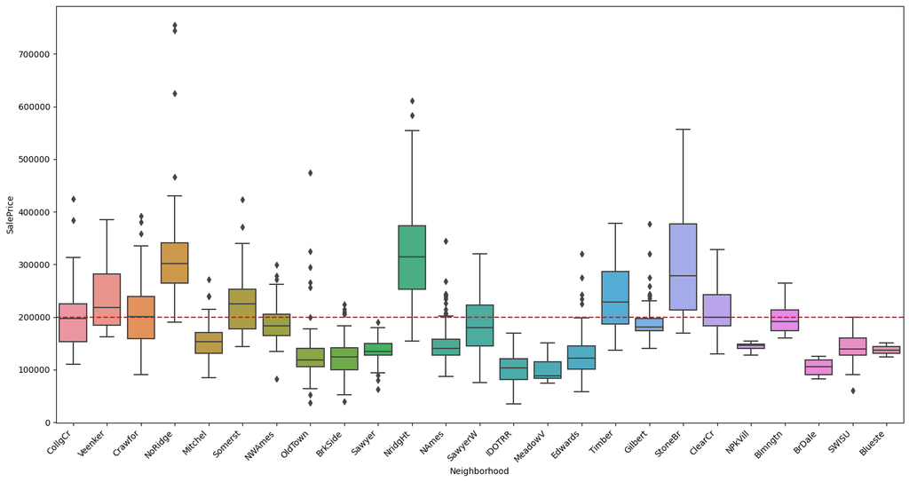

```python
#Neighborhood
plt.figure(figsize=(15, 8))
sns.boxplot(x='Neighborhood', y='SalePrice', data=housing_df)
plt.xticks(rotation=45, ha='right')  # Rotate labels 45 degrees, align right
plt.tight_layout()  # Adjust layout
plt.axhline(y=200000, color='red', linestyle='--') #line above 200000
plt.show()
```

```python
#Neighborhood
#new placeholder object
housing_df['good_neigh'] = 0


for index, value in housing_df.iterrows():
    if (housing_df.loc[index, 'Neighborhood']  == 'NridgHt') | (housing_df.loc[index, 'Neighborhood']  == 'StoneBr') | (housing_df.loc[index, 'Neighborhood']  == 'NoRidge') | (housing_df.loc[index, 'Neighborhood']  == 'Timber') | (housing_df.loc[index, 'Neighborhood']  == 'Somerst') | (housing_df.loc[index, 'Neighborhood']  == 'Veenker'):
        housing_df.loc[index, 'good_neigh'] = 1
    else:
        housing_df.loc[index, 'good_neigh'] = 0

#checking result
housing_df[['good_neigh', 'Neighborhood']].head()
```

|  | good_neigh | Neighborhood |
| --- | --- | --- |
| 0 | 0 | CollgCr |
| 1 | 1 | Veenker |
| 2 | 0 | CollgCr |
| 3 | 0 | Crawfor |
| 4 | 1 | NoRidge |

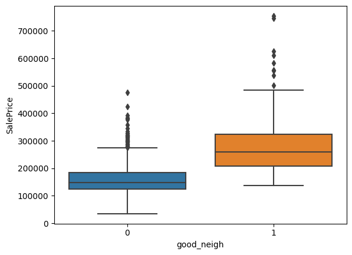

```python
#Is it a good neighborhood? Yes / No
sns.boxplot(x= 'good_neigh',
                 y='SalePrice',
                 data= housing_df)
```

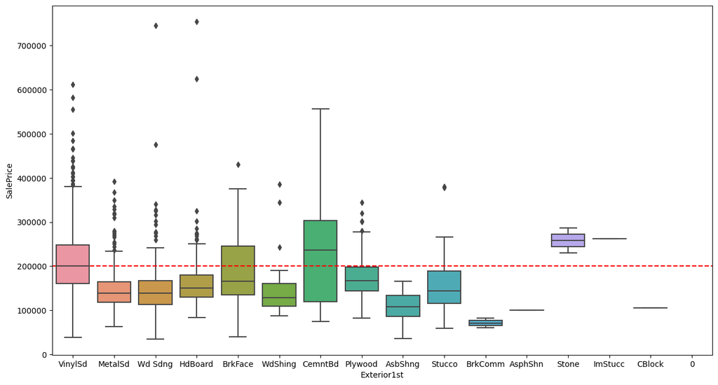

```python
#Exterior1st
plt.figure(figsize=(15, 8))
sns.boxplot(x= 'Exterior1st',
                 y='SalePrice',
                 data= housing_df)
plt.axhline(y=200000, color='red', linestyle='--') #line above 200000
plt.show()
```

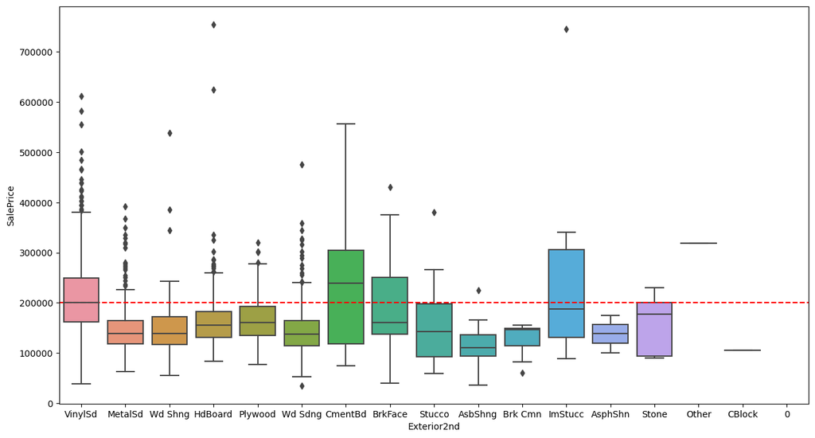

```python
#Exterior2nd
plt.figure(figsize=(15, 8))
sns.boxplot(x= 'Exterior2nd',
                 y='SalePrice',
                 data= housing_df)
plt.axhline(y=200000, color='red', linestyle='--') #line above 200000
plt.show()
```

```python
#Using Exterior 1st and 2nd together
#new placeholder object
housing_df['good_ext'] = 0

#Looping if it meets the conditions for Ex1 and Ex2
for index, value in housing_df.iterrows():
    if (housing_df.loc[index, 'Exterior1st']  == 'VinylSd') | (housing_df.loc[index, 'Exterior1st'] == 'CemntBd') | (housing_df.loc[index, 'Exterior2nd']  == 'VinylSd') | (housing_df.loc[index, 'Exterior2nd'] == 'CemntBd'):
        housing_df.loc[index, 'good_ext'] = 1
    else:
        housing_df.loc[index, 'good_ext'] = 0

#checking result
housing_df[['good_ext', 'Exterior1st', 'Exterior2nd']].head()
```

|  | good_ext | Exterior1st | Exterior2nd |
| --- | --- | --- | --- |
| 0 | 1 | VinylSd | VinylSd |
| 1 | 0 | MetalSd | MetalSd |
| 2 | 1 | VinylSd | VinylSd |
| 3 | 0 | Wd Sdng | Wd Shng |
| 4 | 1 | VinylSd | VinylSd |

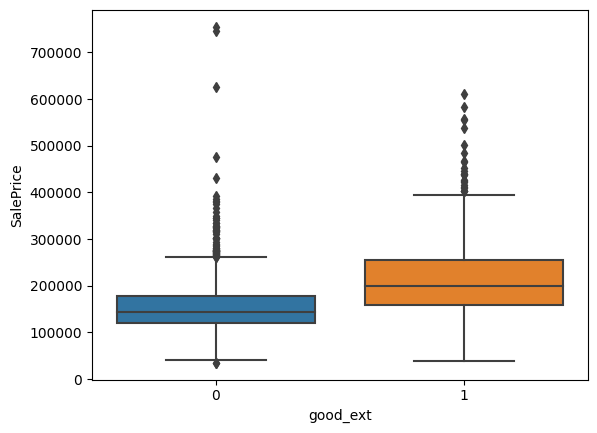

```python
#Is it Good_exterior? Yes/No
sns.boxplot(x= 'good_ext',
                 y='SalePrice',
                 data= housing_df)
```

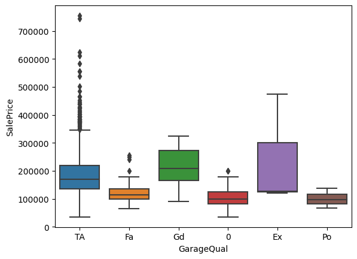

```python
#checking the distribution
sns.boxplot(x= 'GarageQual',
                 y='SalePrice',
                 data= housing_df)
```

```python
#transforming Garage quality is Average?  Yes/No
#new placeholder object
housing_df['grg_qlt_average'] = 0


for index, value in housing_df.iterrows():
    if (housing_df.loc[index, 'GarageQual'] == 'TA') | (housing_df.loc[index, 'GarageQual'] == 'Gd') | (housing_df.loc[index, 'GarageQual'] == 'Ex') :
        housing_df.loc[index, 'grg_qlt_average'] = 1
    else:
        housing_df.loc[index, 'grg_qlt_average'] = 0

#checking result
housing_df[['grg_qlt_average', 'GarageQual']].head()
```

|  | grg_qlt_average | GarageQual |
| --- | --- | --- |
| 0 | 1 | TA |
| 1 | 1 | TA |
| 2 | 1 | TA |
| 3 | 1 | TA |
| 4 | 1 | TA |

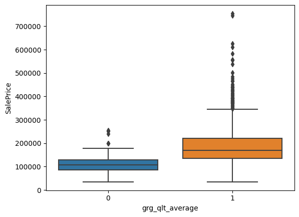

```python
#checking the distribution
sns.boxplot(x= 'grg_qlt_average',
                 y='SalePrice',
                 data= housing_df)
```

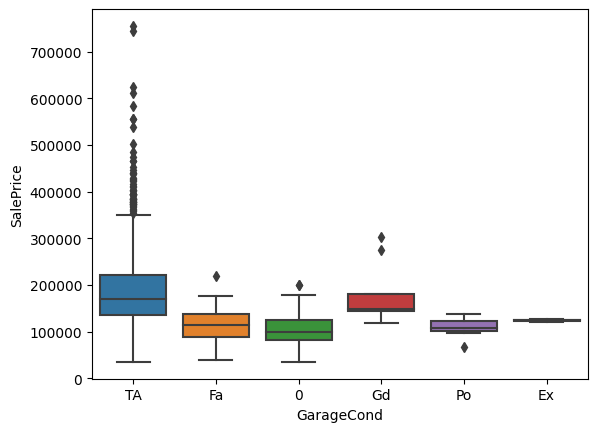

```python
#checking the distribution
sns.boxplot(x= 'GarageCond',
                 y='SalePrice',
                 data= housing_df)
```

```python
#transforming Garage Condition is Average? Yes/No
#new placeholder object
housing_df['grg_cond_avg'] = 0


for index, value in housing_df.iterrows():
    if (housing_df.loc[index, 'GarageCond'] == 'TA') | (housing_df.loc[index, 'GarageCond'] == 'Gd') | (housing_df.loc[index, 'GarageCond'] == 'Ex'):
        housing_df.loc[index, 'grg_cond_avg'] = 1
    else:
        housing_df.loc[index, 'grg_cond_avg'] = 0

#checking result
housing_df[['grg_cond_avg', 'GarageCond']].head()
```

|  | grg_cond_avg | GarageCond |
| --- | --- | --- |
| 0 | 1 | TA |
| 1 | 1 | TA |
| 2 | 1 | TA |
| 3 | 1 | TA |
| 4 | 1 | TA |

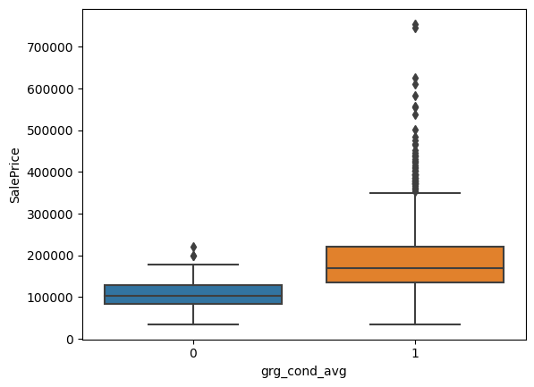

```python
#checking the distribution
sns.boxplot(x= 'grg_cond_avg',
                 y='SalePrice',
                 data= housing_df)
```

### Feature Engineering

**Feature 1: Garage score**

This garage score will help us quickly discern which garages are Built In, Finished, and in Good or Average condition. We decided that if a garage is Built In it will be better for safety purposes, such as not having to worry about broken windows, leaving the car door open or parking tickets. We also wanted a Finished garage because we don't want to worry about spending money on construction, but since it is not that important we used a weight of 0.5. Moreover, the garage has to be above average quality and condition, good enough to be used without having to spend more money on renovations that could lead into not being able to use the garage. Finally, the comfort aspect of not having to look for a parking space every day or walk with grocery bags from the parking space to your house is a big plus for our ideal house.

When looking at the results, we see that most of the scores are higher than 2, meaning that more than half of the houses have an ideal garage.

```python
##Feature 1: Garage score

garage_ftr = ((housing_df["GarageArea"]/housing_df["LotArea"]) + (housing_df["GarageType_BuiltIn"]*2) + (housing_df["GrgFinish_Fin"]*0.5) + (housing_df["grg_qlt_average"]*0.5) + (housing_df["grg_cond_avg"]*2) )
housing_df["garage_ftr"] = garage_ftr

housing_df['garage_ftr'].describe()
```

```
count    2919.000000
mean        2.588309
std         0.964059
min         0.000000
25%         2.535141
50%         2.557650
75%         3.029958
max         5.244444
Name: garage_ftr, dtype: float64
```

```python
#checking the correlation
housing_df[['garage_ftr', 'SalePrice']].corr(method = 'pearson').round(decimals=2)
```

|  | garage_ftr | SalePrice |
| --- | --- | --- |
| garage_ftr | 1.00 | 0.42 |
| SalePrice | 0.42 | 1.00 |

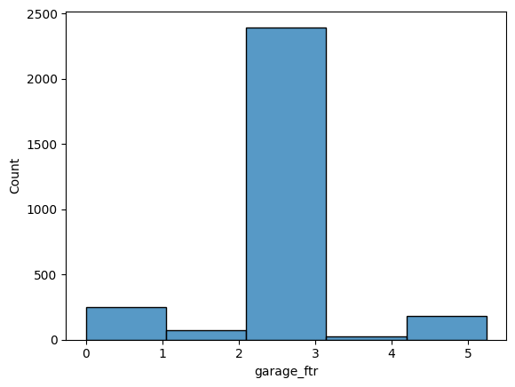

```python
#checking the distribution
sns.histplot(x= 'garage_ftr',
                 data= housing_df, bins=5)
```

**Feature 2: Garage age**

The garage age is an important feature for us because it can compliment well with the garage score and in some cases the garage has been built years after the house, so instead of having the year, we created a feature that can group the age and easily help see if the garage is new, recent or old.

```python
#Feature 2: Garage Age

housing_df['grg_age'] = housing_df['GarageYrBlt'] - housing_df['YearBuilt']

#new placeholder object
housing_df['grg_age_cond'] = 0


for index, value in housing_df.iterrows():
    if housing_df.loc[index, 'grg_age'] <= 5:
        housing_df.loc[index, 'grg_age_cond'] = 'new'
    elif housing_df.loc[index, 'grg_age'] <= 20:
        housing_df.loc[index, 'grg_age_cond'] = 'recent'
    else:
        housing_df.loc[index, 'grg_age_cond'] = 'old'


#checking result
housing_df[['grg_age_cond', 'grg_age', 'YearBuilt', 'GarageYrBlt']].head()
```

|  | grg_age_cond | grg_age | YearBuilt | GarageYrBlt |
| --- | --- | --- | --- | --- |
| 0 | new | 0.0 | 2003 | 2003.0 |
| 1 | new | 0.0 | 1976 | 1976.0 |
| 2 | new | 0.0 | 2001 | 2001.0 |
| 3 | old | 83.0 | 1915 | 1998.0 |
| 4 | new | 0.0 | 2000 | 2000.0 |

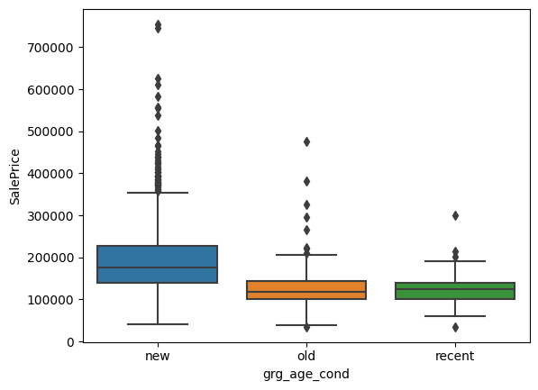

```python
#checking the distribution
sns.boxplot(x= 'grg_age_cond',
                 y='SalePrice',
                 data= housing_df)
```

```python
#Transforming grg_year_condition into dummies
grg_age_cond_dummie = pd.get_dummies(housing_df['grg_age_cond'], prefix='grg_age_cond').astype(int)
housing_df = pd.concat([housing_df,grg_age_cond_dummie], axis=1)

grg_age_cond_dummie.head()
```

|  | grg_age_cond_new | grg_age_cond_old | grg_age_cond_recent |
| --- | --- | --- | --- |
| 0 | 1 | 0 | 0 |
| 1 | 1 | 0 | 0 |
| 2 | 1 | 0 | 0 |
| 3 | 0 | 1 | 0 |
| 4 | 1 | 0 | 0 |

```python
#checking correlation
housing_df[['grg_age_cond_new','grg_age_cond_old','grg_age_cond_recent', 'SalePrice']].corr(method = 'pearson').round(decimals=2)
```

|  | grg_age_cond_new | grg_age_cond_old | grg_age_cond_recent | SalePrice |
| --- | --- | --- | --- | --- |
| grg_age_cond_new | 1.00 | -0.82 | -0.50 | 0.32 |
| grg_age_cond_old | -0.82 | 1.00 | -0.09 | -0.26 |
| grg_age_cond_recent | -0.50 | -0.09 | 1.00 | -0.17 |
| SalePrice | 0.32 | -0.26 | -0.17 | 1.00 |

**Feature 3: House age**

We created a categorical feature to differentiate the age of the house based on the year it was built vs the year it was sold. This was a very important variable because by knowing if its a new or very old house we can easily look at other variables such as overall condition an quality of the house and have an idea of how much work it will need if you buy it. For example an very old house with excellent quality and condition is far more attractive than a new house with a low quality and condition.

```python
##Feature 3: House Age
housing_df['house_age'] = housing_df["YrSold"] - housing_df["YearBuilt"]

#new placeholder
housing_df['house_cond'] = 0


for index, value in housing_df.iterrows():
    if (housing_df.loc[index, 'house_age'] <= 5) :
        housing_df.loc[index, 'house_cond'] = 'New'

    elif housing_df.loc[index, 'house_age'] <= 20:
        housing_df.loc[index, 'house_cond'] = 'Recent'

    elif housing_df.loc[index, 'house_age'] <= 60:
        housing_df.loc[index, 'house_cond'] = 'Old'

    else:
        housing_df.loc[index, 'house_cond'] = 'Very_old'

#checking result
housing_df[['house_cond', 'house_age']].head()
```

|  | house_cond | house_age |
| --- | --- | --- |
| 0 | New | 5 |
| 1 | Old | 31 |
| 2 | Recent | 7 |
| 3 | Very_old | 91 |
| 4 | Recent | 8 |

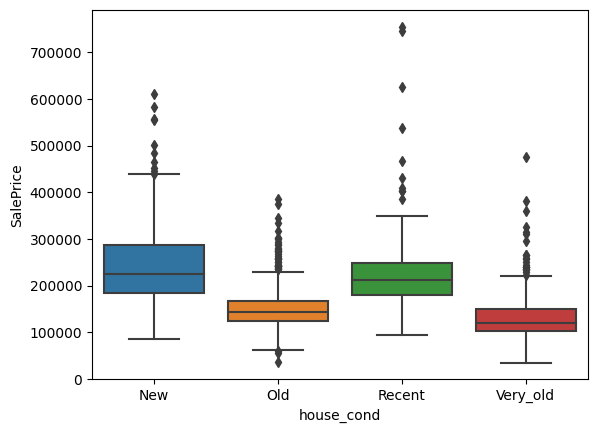

```python
#Checking the distribution
sns.boxplot(x= 'house_cond',
                 y='SalePrice',
                 data= housing_df)
```

```python
#transforming into 0 and 1
house_cond_dummies = pd.get_dummies(housing_df['house_cond'], prefix='house_cond').astype(int)
housing_df = pd.concat([housing_df,house_cond_dummies], axis=1)

house_cond_dummies.head()
```

|  | house_cond_New | house_cond_Old | house_cond_Recent | house_cond_Very_old |
| --- | --- | --- | --- | --- |
| 0 | 1 | 0 | 0 | 0 |
| 1 | 0 | 1 | 0 | 0 |
| 2 | 0 | 0 | 1 | 0 |
| 3 | 0 | 0 | 0 | 1 |
| 4 | 0 | 0 | 1 | 0 |

```python
#checking correlation
housing_df[['house_cond_New','house_cond_Old','house_cond_Recent','house_cond_Very_old', 'SalePrice']].corr(method = 'pearson').round(decimals=2)
```

|  | house_cond_New | house_cond_Old | house_cond_Recent | house_cond_Very_old | SalePrice |
| --- | --- | --- | --- | --- | --- |
| house_cond_New | 1.00 | -0.43 | -0.24 | -0.26 | 0.43 |
| house_cond_Old | -0.43 | 1.00 | -0.38 | -0.42 | -0.32 |
| house_cond_Recent | -0.24 | -0.38 | 1.00 | -0.23 | 0.26 |
| house_cond_Very_old | -0.26 | -0.42 | -0.23 | 1.00 | -0.30 |
| SalePrice | 0.43 | -0.32 | 0.26 | -0.30 | 1.00 |

**Feature 4: Ideal location**

We created a score based on the neighborhood, proximity to parks, schools, hospitals, and the privacy. For example houses that are in a Cul-de-sac are more convenient for families with kids or is you want less noise at night since there is not traffic jam and it is not a concurred area. Moreover, Frontage on 3 sides of property was also considered as private because the owners won't have to worry about noise from neighboors, it also gives different access points.

```python
#Feature 4: Ideal location

ideal_location = (housing_df["good_neigh"]*2) + (housing_df["Condition1_PosA"]+housing_df["Condition1_PosN"]+housing_df["Condition2_PosA"]+housing_df["Condition2_PosN"])*0.6+(housing_df["LotConfig_CulDSac"]+housing_df["LotConfig_FR3"])*1
housing_df["ideal_location"] = ideal_location
housing_df["ideal_location"].describe()
```

```
count    2919.000000
mean        0.466667
std         0.847580
min         0.000000
25%         0.000000
50%         0.000000
75%         0.600000
max         3.600000
Name: ideal_location, dtype: float64
```

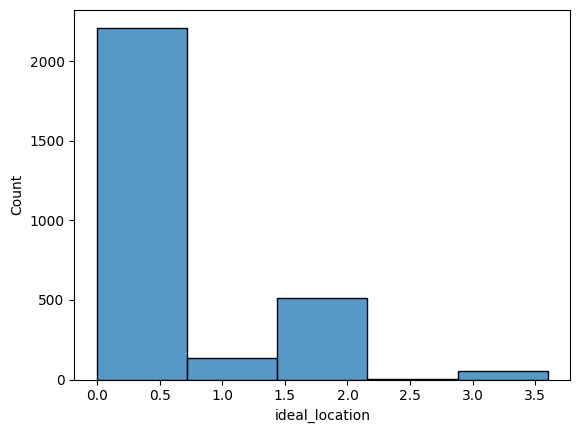

```python
#Checking the distribution
sns.histplot(x= 'ideal_location',
                 data= housing_df, bins=5)
```

```python
#Checking the correlation
housing_df[['ideal_location', 'SalePrice']].corr(method = 'pearson').round(decimals=2)
```

|  | ideal_location | SalePrice |
| --- | --- | --- |
| ideal_location | 1.0 | 0.6 |
| SalePrice | 0.6 | 1.0 |

**Feature 5: Basement Score**

```python
#Feature 5: Basement score
ideal_bsmt = ((housing_df['BsmtFinSF1'] + housing_df['BsmtFinSF2'])/ (housing_df['TotalBsmtSF']+1))*(housing_df['BsmtCond_TA']+housing_df['BsmtCond_Gd'])*(housing_df['BsmtQual_Ex']+housing_df['BsmtQual_Gd'])*(housing_df['BsmtExposure_Gd']+housing_df['BsmtExposure_Av'])
housing_df["ideal_bsmt"] = ideal_bsmt
housing_df["ideal_bsmt"].describe()
```

```
count    2919.000000
mean        0.111576
std         0.279219
min         0.000000
25%         0.000000
50%         0.000000
75%         0.000000
max         0.999594
Name: ideal_bsmt, dtype: float64
```

```python
#Checking the distribution
sns.scatterplot(x= 'ideal_bsmt',
                 y='SalePrice',
                 data= housing_df)
```

[output not shown]

```python
#checking the correlation
housing_df[['ideal_bsmt', 'SalePrice']].corr(method = 'pearson').round(decimals=2)
```

[output not shown]

**Feature 6: Total Bathrooms**

A house with more bathrooms is more convenient because it reduces waiting times for the big family. It is important to know how many each house has because it is easier for the buyer to make a quick decision based on his needs. Moreover, houses with aditional half bathrooms are very convenient when having gatherings, since they won't have access to the owners private things.

```python
# Feature 6: Total Bathrooms
Total_Bathrooms = housing_df["FullBath"] + (0.5 * housing_df["HalfBath"]) + housing_df["BsmtFullBath"]
housing_df["Total_Bathrooms"] = Total_Bathrooms
housing_df["Total_Bathrooms"].describe()
```

[output not shown]

```python
#Checking the distribution
sns.boxplot(x= 'Total_Bathrooms',
                 y='SalePrice',
                 data= housing_df)
```

[output not shown]

```python
#checking the correlation
housing_df[['Total_Bathrooms', 'SalePrice']].corr(method = 'pearson').round(decimals=2)
```

[output not shown]